# ML_HW1

(a) loading data

```python
import matplotlib.pyplot as plt
import pandas as pd

import seaborn as sns
import numpy as np



from sklearn.metrics import confusion_matrix
from sklearn.neighbors import KNeighborsClassifier
from sklearn.metrics import accuracy_score


dt = pd.read_csv('C:/Users/simeon/Desktop/ML_HW1_data.csv')
dt=pd.DataFrame(dt)
print(dt.head())
```

```
   pelvic_incidence  pelvic_tilt  lumbar_lordosis  sacral_slope  \
0         63.027818    22.552586        39.609117     40.475232
1         39.056951    10.060991        25.015378     28.995960
2         68.832021    22.218482        50.092194     46.613539
3         69.297008    24.652878        44.311238     44.644130
4         49.712859     9.652075        28.317406     40.060784

   pelvic_radius  spondyloisthesis    class1
0      98.672917         -0.254400  Abnormal
1     114.405425          4.564259  Abnormal
2     105.985135         -3.530317  Abnormal
3     101.868495         11.211523  Abnormal
4     108.168725          7.918501  Abnormal
```

(b) pre processing Exploratory and data analysis

i.

```
(-50, 150)
```

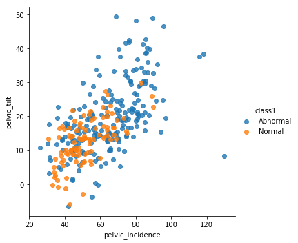

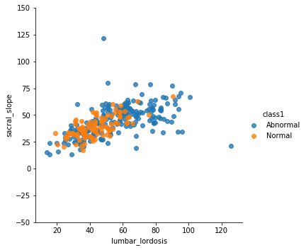

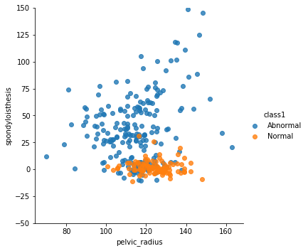

```python
print(sns.lmplot( x="pelvic_incidence", y="pelvic_tilt", data=dt, fit_reg=False, hue='class1', legend=True))

print(sns.lmplot( x="lumbar_lordosis", y="sacral_slope", data=dt, fit_reg=False, hue='class1', legend=True))
plt.ylim(-50,150)
print(sns.lmplot( x="pelvic_radius", y="spondyloisthesis", data=dt, fit_reg=False, hue='class1', legend=True))
plt.ylim(-50,150)
```

ii.

```
<function matplotlib.pyplot.show(*args, **kw)>
```

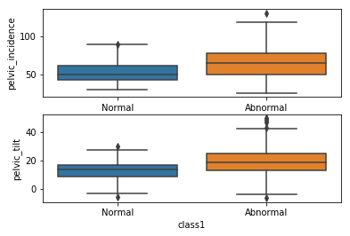

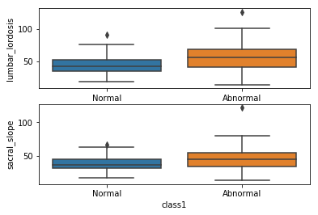

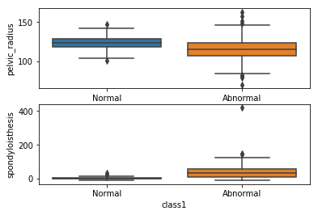

```python
fig, ax = plt.subplots(2,1)

sns.boxplot(x="class1", y="pelvic_incidence", data=dt, order=["Normal", "Abnormal"],ax=ax[0])


sns.boxplot(x="class1", y="pelvic_tilt", data=dt, order=["Normal", "Abnormal"],ax=ax[1])
plt.show

fig, ax = plt.subplots(2,1)

sns.boxplot(x="class1", y="lumbar_lordosis", data=dt, order=["Normal", "Abnormal"],ax=ax[0])


sns.boxplot(x="class1", y="sacral_slope", data=dt, order=["Normal", "Abnormal"],ax=ax[1])
plt.show

fig, ax = plt.subplots(2,1)

sns.boxplot(x="class1", y="pelvic_radius", data=dt, order=["Normal", "Abnormal"],ax=ax[0])


sns.boxplot(x="class1", y="spondyloisthesis", data=dt, order=["Normal", "Abnormal"],ax=ax[1])
plt.show
```

iii. creating training and testing sets

```python
a = dt[dt.class1 =="Normal"]

a = np.array(a)
tr_no = a[0:70,]
a = dt[dt.class1 =="Normal"]

a = np.array(a)
tst_no = a[70:310,]


a = dt[dt.class1 =="Abnormal"]

a = np.array(a)
tr_ab = a[0:140,]

a = dt[dt.class1 =="Abnormal"]

a = np.array(a)
tst_ab = a[140:310,]
train = np.concatenate([tr_no, tr_ab])

test = np.concatenate([tst_no, tst_ab])

#train = pd.DataFrame(train)
#train.columns = ['pelvic_incidence',	'pelvic_tilt',	'lumbar_lordosis',	'sacral_slope',	'pelvic_radius',	'spondyloisthesis',	'class1']

x_train = train[:,0:6]
y_train = train[:,6]
x_test = test[:,0:6]
y_test =test[:,6]
#######################
```

(c) Classification using KNN on Vertebral Column Data Set

i.& ii.

```
error rate is  0.13 % for K-Value: 1
error rate is  0.17000000000000004 % for K-Value: 2
error rate is  0.07999999999999996 % for K-Value: 3
error rate is  0.12 % for K-Value: 4
error rate is  0.09999999999999998 % for K-Value: 5
error rate is  0.15000000000000002 % for K-Value: 6
error rate is  0.12 % for K-Value: 7
error rate is  0.16000000000000003 % for K-Value: 8
error rate is  0.13 % for K-Value: 9
error rate is  0.15000000000000002 % for K-Value: 10
error rate is  0.12 % for K-Value: 11
error rate is  0.13 % for K-Value: 12
error rate is  0.12 % for K-Value: 13
error rate is  0.12 % for K-Value: 14
error rate is  0.10999999999999999 % for K-Value: 15
error rate is  0.10999999999999999 % for K-Value: 16
error rate is  0.10999999999999999 % for K-Value: 17
error rate is  0.12 % for K-Value: 18
error rate is  0.10999999999999999 % for K-Value: 19
error rate is  0.10999999999999999 % for K-Value: 20
error rate is  0.09999999999999998 % for K-Value: 21
error rate is  0.10999999999999999 % for K-Value: 22
error rate is  0.10999999999999999 % for K-Value: 23
error rate is  0.12 % for K-Value: 24
error rate is  0.10999999999999999 % for K-Value: 25
error rate is  0.13 % for K-Value: 26
error rate is  0.12 % for K-Value: 27
error rate is  0.13 % for K-Value: 28
error rate is  0.12 % for K-Value: 29
error rate is  0.13 % for K-Value: 30
error rate is  0.10999999999999999 % for K-Value: 31
error rate is  0.13 % for K-Value: 32
error rate is  0.12 % for K-Value: 33
error rate is  0.12 % for K-Value: 34
error rate is  0.10999999999999999 % for K-Value: 35
error rate is  0.12 % for K-Value: 36
error rate is  0.10999999999999999 % for K-Value: 37
error rate is  0.10999999999999999 % for K-Value: 38
error rate is  0.10999999999999999 % for K-Value: 39
error rate is  0.10999999999999999 % for K-Value: 40
```

[output cut: 361 more lines]

```
error rate is  0.33333333333333337 % for K-Value: 194
error rate is  0.33333333333333337 % for K-Value: 195
error rate is  0.33333333333333337 % for K-Value: 196
error rate is  0.33333333333333337 % for K-Value: 197
error rate is  0.33333333333333337 % for K-Value: 198
error rate is  0.33333333333333337 % for K-Value: 199
error rate is  0.33333333333333337 % for K-Value: 200
error rate is  0.33333333333333337 % for K-Value: 201
error rate is  0.33333333333333337 % for K-Value: 202
error rate is  0.33333333333333337 % for K-Value: 203
error rate is  0.33333333333333337 % for K-Value: 204
error rate is  0.33333333333333337 % for K-Value: 205
error rate is  0.33333333333333337 % for K-Value: 206
error rate is  0.33333333333333337 % for K-Value: 207
error rate is  0.33333333333333337 % for K-Value: 208
```

```
No handles with labels found to put in legend.
```

```
Legend
[[129  11]
 [ 11  59]]
[[69  1]
 [ 7 23]]
0.8428571428571429
0.7666666666666667
0.5
0.875
0.8428571428571429
0.9583333333333334
0.8428571428571429
0.8518518518518519
```

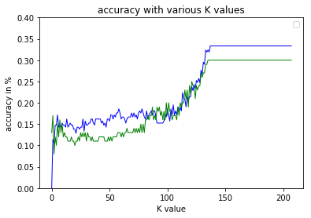

```python
train_error = list(range(208))
test_error = list(range(208))

for K in range(208):
 K_value = K+1
 neigh = KNeighborsClassifier(n_neighbors = K_value, weights='uniform', algorithm='auto', metric = 'euclidean')
 neigh.fit(x_train, y_train)
 y_pred_test = neigh.predict(x_test)
 print( "error rate is ", 1-accuracy_score(y_test,y_pred_test),"% for K-Value:",K_value)
 test_error[K] = 1- accuracy_score(y_test, y_pred_test)

for K in range(208):
 K_value = K+1
 neigh = KNeighborsClassifier(n_neighbors = K_value, weights='uniform', algorithm='auto', metric = 'euclidean')
 neigh.fit(x_train, y_train)
 y_pred_train = neigh.predict(x_train)
 print( "error rate is ", 1- accuracy_score(y_train,y_pred_train),"% for K-Value:",K_value)
 train_error[K] = 1- accuracy_score(y_train, y_pred_train)


K_value = range(208)
#plotting results
plt.ylim(0,.4)
plt.plot( K_value, train_error, marker='', markerfacecolor='blue', markersize=1, color='blue', linewidth=1)
plt.plot( K_value, test_error,  marker='', color='green', linewidth=1)
plt.title('accuracy with various K values')
plt.xlabel("K value")
plt.ylabel('accuracy in %')
print(plt.legend())



# we can see that our highest accuracy and lowest error occurs at a k value of 3, with accuracy = 81% test and 84% train however the highest total accuracy i which we add the two values together
#happens when k=1 with accuracy = 74% test and 100% train, to test we will try both of these values for K






neigh = KNeighborsClassifier(n_neighbors = 3, weights='uniform', algorithm='auto', metric = 'euclidean')

neigh.fit(x_train, y_train)
labels = ['Abnormal', 'Normal']
y_pred_train = neigh.predict(x_train)
y_pred_test = neigh.predict(x_test)
print(confusion_matrix(y_train, y_pred_train, labels))


print(confusion_matrix(y_test, y_pred_test))



#both output identical confusion matrixes
#therefore we will say k = 3 is our k*
#true positive rate for train   aka recall
print(59/(59+11))
#true positive rate for test   aka recall
print(23/(23+7))

# true negative rate for train
print(11/(11+11))
# true negative rate for test
print(7/(7+1))
# precision for train
print(59/(59+11))
# precision for test
print(23/(23+1))

#F-score for train
print(2*((0.8428571428571429*.8428571428571429)/(0.8428571428571429+.8428571428571429)))

#F-score for test
print(2*((.9583333333333334*.7666666666666667)/(.9583333333333334+.7666666666666667)))
```

iii.

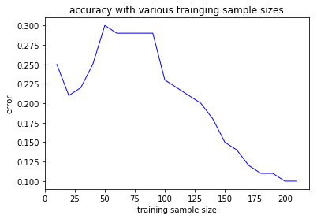

```python
N = list(range(10, 211, 10))
plot_error = []
for i in N:
    tr_no1 = tr_no[0:round(i/3),:]
    tr_ab1 = tr_ab[0:(i-round(i/3)),:]
    train = np.concatenate([tr_no1, tr_ab1])
    x_train = train[:,0:6]
    y_train = train[:,6]
    num =int( i/10)


    test_error= []
    for K in list(range(1, i,5)):
        K_value = K
        neigh = KNeighborsClassifier(n_neighbors = K_value, weights='uniform', algorithm='auto', metric = 'euclidean')
        neigh.fit(x_train, y_train)
        y_pred_test = neigh.predict(x_test)
        ( "error rate is ", 1-accuracy_score(y_test,y_pred_test),"% for K-Value:",K_value)
        bwb = ( 1- accuracy_score(y_test, y_pred_test))
        test_error.append(bwb)
        minpos = test_error.index(min(test_error))
        k_use = (minpos*5)+1

    neigh = KNeighborsClassifier(n_neighbors = k_use, weights='uniform', algorithm='auto', metric = 'euclidean')
    neigh.fit(x_train, y_train)
    y_pred_test = neigh.predict(x_test)
    bwb2 = ( 1- accuracy_score(y_test, y_pred_test))
    plot_error.append(bwb2)


plt.plot( N, plot_error, marker='', markerfacecolor='blue', markersize=1, color='blue', linewidth=1)
plt.title('accuracy with various trainging sample sizes')
plt.xlabel("training sample size")
plt.ylabel('error')
```

as we can see, the larger the training sample the better our model, with some exceptions occuring between a sample size of 30 and 100

D. Replace the Euclidean metric with the following metrics and test them. Summarize the test errors

```
error rate is  0.13 % for K-Value: 1
error rate is  0.15000000000000002 % for K-Value: 6
error rate is  0.12 % for K-Value: 11
error rate is  0.10999999999999999 % for K-Value: 16
error rate is  0.09999999999999998 % for K-Value: 21
error rate is  0.13 % for K-Value: 26
error rate is  0.10999999999999999 % for K-Value: 31
error rate is  0.12 % for K-Value: 36
error rate is  0.10999999999999999 % for K-Value: 41
error rate is  0.12 % for K-Value: 46
error rate is  0.10999999999999999 % for K-Value: 51
error rate is  0.12 % for K-Value: 56
error rate is  0.12 % for K-Value: 61
error rate is  0.14 % for K-Value: 66
error rate is  0.13 % for K-Value: 71
error rate is  0.14 % for K-Value: 76
error rate is  0.13 % for K-Value: 81
error rate is  0.17000000000000004 % for K-Value: 86
error rate is  0.16000000000000003 % for K-Value: 91
error rate is  0.18000000000000005 % for K-Value: 96
error rate is  0.17000000000000004 % for K-Value: 101
error rate is  0.17000000000000004 % for K-Value: 106
error rate is  0.17000000000000004 % for K-Value: 111
error rate is  0.22999999999999998 % for K-Value: 116
error rate is  0.21999999999999997 % for K-Value: 121
error rate is  0.24 % for K-Value: 126
error rate is  0.26 % for K-Value: 131
error rate is  0.30000000000000004 % for K-Value: 136
error rate is  0.30000000000000004 % for K-Value: 141
error rate is  0.30000000000000004 % for K-Value: 146
error rate is  0.30000000000000004 % for K-Value: 151
error rate is  0.30000000000000004 % for K-Value: 156
error rate is  0.30000000000000004 % for K-Value: 161
error rate is  0.30000000000000004 % for K-Value: 166
error rate is  0.30000000000000004 % for K-Value: 171
error rate is  0.30000000000000004 % for K-Value: 176
error rate is  0.30000000000000004 % for K-Value: 181
error rate is  0.30000000000000004 % for K-Value: 186
error rate is  0.30000000000000004 % for K-Value: 191
0.1
0.2
0.30000000000000004
0.4
0.5
0.6
0.7000000000000001
0.8
0.9
1.0
1 minowski 2 manhattan 3 log10 = .1 4 chebyshev 5 mahalanobis
```

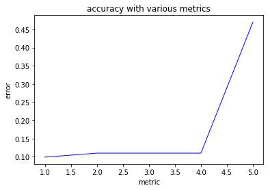

```python
test_error = []
for K in list(range(1, 196,5)):
        K_value = K
        neigh = KNeighborsClassifier(n_neighbors = K_value, weights='uniform', algorithm='auto', metric = 'minkowski')
        neigh.fit(x_train, y_train)
        y_pred_test = neigh.predict(x_test)
        print( "error rate is ", 1-accuracy_score(y_test,y_pred_test),"% for K-Value:",K_value)
        bwb = ( 1- accuracy_score(y_test, y_pred_test))
        test_error.append(bwb)
        minpos = int((test_error.index(min(test_error))))
        k_use = (minpos*5)+1

neigh = KNeighborsClassifier(n_neighbors = k_use, weights='uniform', algorithm='auto', metric = 'minkowski')
neigh.fit(x_train, y_train)
y_pred_test = neigh.predict(x_test)

test_error_minowski = 1- accuracy_score(y_test, y_pred_test)


# Manhattan
test_error = []
for K in list(range(1, 196,5)):
        K_value = K
        neigh = KNeighborsClassifier(n_neighbors = K_value, weights='uniform', algorithm='auto', metric = 'manhattan')
        neigh.fit(x_train, y_train)
        y_pred_test = neigh.predict(x_test)
        ( "error rate is ", 1-accuracy_score(y_test,y_pred_test),"% for K-Value:",K_value)
        bwb = ( 1- accuracy_score(y_test, y_pred_test))
        test_error.append(bwb)
        minpos = test_error.index(min(test_error))
        k_use = (minpos*5)+1

neigh = KNeighborsClassifier(n_neighbors = k_use, weights='uniform', algorithm='auto', metric = 'manhattan')
neigh.fit(x_train, y_train)
y_pred_test = neigh.predict(x_test)

test_error_manhattan = 1- accuracy_score(y_test, y_pred_test)



#minoswki with various logbase(10) values

neigh = KNeighborsClassifier(n_neighbors = k_use, weights='uniform', algorithm='auto', metric = 'minkowski', p=1)
neigh.fit(x_train, y_train)
y_pred_test = neigh.predict(x_test)

test_error = []
test_error_minowski_log = []
for i in np.linspace(.1,1,10):
    print(i)
    neigh = KNeighborsClassifier(n_neighbors = k_use, weights='uniform', algorithm='auto', metric = 'minkowski', p = 10**i)
    neigh.fit(x_train, y_train)
    y_pred_test = neigh.predict(x_test)
    test_error_minowski_log.append(1- accuracy_score(y_test, y_pred_test))

# the best log10 P is .1 or .3
# Chebyshev
test_error = []
for K in list(range(1, 196,5)):
        K_value = K
        neigh = KNeighborsClassifier(n_neighbors = K_value, weights='uniform', algorithm='auto', metric = 'chebyshev')
        neigh.fit(x_train, y_train)
        y_pred_test = neigh.predict(x_test)
        ( "error rate is ", 1-accuracy_score(y_test,y_pred_test),"% for K-Value:",K_value)
        bwb = ( 1- accuracy_score(y_test, y_pred_test))
        test_error.append(bwb)
        minpos = test_error.index(min(test_error))
        k_use = (minpos*5)+1

neigh = KNeighborsClassifier(n_neighbors = k_use, weights='uniform', algorithm='auto', metric = 'chebyshev')
neigh.fit(x_train, y_train)
y_pred_test = neigh.predict(x_test)

test_error_cheb = 1- accuracy_score(y_test, y_pred_test)

#mahalanobis

from sklearn.datasets import make_classification
from sklearn.neighbors import DistanceMetric
x = x_train
y = y_train
xt = x_train
yt = y_train
test_error = []
for K in list(range(1, 99,5)):
        x, y = make_classification()
        xt, yt = make_classification()
        DistanceMetric.get_metric('mahalanobis', V=np.cov(x))
        K_value = K
        neigh = KNeighborsClassifier(n_neighbors =K,algorithm='brute',  metric='mahalanobis', metric_params={'V': np.cov(x)})
        neigh.fit(x,y)
        y_pred_test = neigh.predict(xt)
        last = []
        for i in range(len(y)):
            if y[i] != y_pred_test[i]:
                last.append(i)
        accuracy = len(last)/len(y_pred_test)
        bwb = ( 1- accuracy)
        test_error.append(bwb)
        minpos = test_error.index(min(test_error))
        k_use = (minpos*5)+1

#optimal k = 4

x = x_train
y = y_train
xt = x_train
yt = y_train
test_error = []
for K in list(range(1, 99,5)):
        x, y = make_classification()
        xt, yt = make_classification()
        DistanceMetric.get_metric('mahalanobis', V=np.cov(x))
        K_value = K
        neigh = KNeighborsClassifier(n_neighbors =4,algorithm='brute',  metric='mahalanobis', metric_params={'V': np.cov(x)})
        neigh.fit(x,y)
        y_pred_test = neigh.predict(xt)
        last = []
        for i in range(len(y)):
            if y[i] != y_pred_test[i]:
                last.append(i)
        accuracy = len(last)/len(y_pred_test)
        bwb = ( 1- accuracy)
        test_error.append(bwb)
        minpos = test_error.index(min(test_error))
        k_use = (minpos*5)+1

plotable_y = [.099,.10999,.10999,.10999,.47 ]
plotable_x =[1,2,3,4,5]
plotable_x_lab = {'1 minowski','2 manhattan','3 log10 = .1','4 chebyshev','5 mahalanobis'}

plt.plot( plotable_x, plotable_y, marker='', markerfacecolor='blue', markersize=1, color='blue', linewidth=1)
plt.title('accuracy with various metrics')
plt.xlabel("metric")
plt.ylabel('error')
print('1 minowski','2 manhattan','3 log10 = .1','4 chebyshev','5 mahalanobis')
```

the best errors that were achieved occured with our various types was with the minowki type in which we achieved an error of .0999

e) The majority polling decision can be replaced by weighted decision, in which the weight of each point in voting is inversely proportional to its distance from the query/test data point. In this case, closer neighbors of a query point will have a greater influence than neighbors which are further away. Use weighted voting with Euclidean, Manhattan, and Chebyshev distances and report the best test errors

```python
test_error = []
for K in list(range(1, 196,5)):
        K_value = K
        neigh = KNeighborsClassifier(n_neighbors = K_value, weights='distance', algorithm='auto', metric = 'euclidean')
        neigh.fit(x_train, y_train)
        y_pred_test = neigh.predict(x_test)
        ( "error rate is ", 1-accuracy_score(y_test,y_pred_test),"% for K-Value:",K_value)
        bwb = ( 1- accuracy_score(y_test, y_pred_test))
        test_error.append(bwb)
        minpos = test_error.index(min(test_error))
        k_use = (minpos*5)+1

neigh = KNeighborsClassifier(n_neighbors = k_use, weights='distance', algorithm='auto', metric = 'euclidean')
neigh.fit(x_train, y_train)
y_pred_test = neigh.predict(x_test)

test_error_euclidean = 1- accuracy_score(y_test, y_pred_test)





test_error = []
for K in list(range(1, 196,5)):
        K_value = K
        neigh = KNeighborsClassifier(n_neighbors = K_value, weights='distance', algorithm='auto', metric = 'manhattan')
        neigh.fit(x_train, y_train)
        y_pred_test = neigh.predict(x_test)
        ( "error rate is ", 1-accuracy_score(y_test,y_pred_test),"% for K-Value:",K_value)
        bwb = ( 1- accuracy_score(y_test, y_pred_test))
        test_error.append(bwb)
        minpos = test_error.index(min(test_error))
        k_use = (minpos*5)+1

neigh = KNeighborsClassifier(n_neighbors = k_use, weights='distance', algorithm='auto', metric = 'manhattan')
neigh.fit(x_train, y_train)
y_pred_test = neigh.predict(x_test)

test_error_manhattan = 1- accuracy_score(y_test, y_pred_test)

test_error = []
for K in list(range(1, 196,5)):
        K_value = K
        neigh = KNeighborsClassifier(n_neighbors = K_value, weights='distance', algorithm='auto', metric = 'chebyshev')
        neigh.fit(x_train, y_train)
        y_pred_test = neigh.predict(x_test)
        ( "error rate is ", 1-accuracy_score(y_test,y_pred_test),"% for K-Value:",K_value)
        bwb = ( 1- accuracy_score(y_test, y_pred_test))
        test_error.append(bwb)
        minpos = test_error.index(min(test_error))
        k_use = (minpos*5)+1

neigh = KNeighborsClassifier(n_neighbors = k_use, weights='distance', algorithm='auto', metric = 'chebyshev')
neigh.fit(x_train, y_train)
y_pred_test = neigh.predict(x_test)

test_error_cheb = 1- accuracy_score(y_test, y_pred_test)

print(test_error_euclidean)
print(test_error_manhattan)
print(test_error_cheb)
```

```
0.09999999999999998
0.09999999999999998
0.10999999999999999
```

we can see that these weights did improve the accuracy of the manhattan type but the others remained the same

(f) What is the lowest training error rate you achieved in this homework?

the lowest test error rate that i got was with a euclidean type and a k value of 3 and uniform weights 0.07999999999999996. the lowest train error rate that i got was zero, this occured with the same parameters but with a k value of 1